# Part I - FORD GOBIKE SYSTEM DATA EXPLORATION

## Introduction

This dataset contains the Ford GoBike System data which includes information about individual rides made in a bike sharing system covering the greater San Francisco Bay area.

The dataset contains information about 183412 rides made in February 2019.

## Preliminary Wrangling

> Load in your dataset and describe its properties through the questions below. Try and motivate your exploration goals through this section.

```
<Response [200]>
```

```
['.config', '201902-fordgobike-tripdata.csv', 'sample_data']
```

|  | duration_sec | start_time | end_time | start_station_id | start_station_name | start_station_latitude | start_station_longitude | end_station_id | end_station_name | end_station_latitude | end_station_longitude | bike_id | user_type | member_birth_year | member_gender | bike_share_for_all_trip |
| --- | --- | --- | --- | --- | --- | --- | --- | --- | --- | --- | --- | --- | --- | --- | --- | --- |
| 0 | 52185 | 2019-02-28 17:32:10.1450 | 2019-03-01 08:01:55.9750 | 21.0 | Montgomery St BART Station (Market St at 2nd St) | 37.789625 | -122.400811 | 13.0 | Commercial St at Montgomery St | 37.794231 | -122.402923 | 4902 | Customer | 1984.0 | Male | No |
| 1 | 42521 | 2019-02-28 18:53:21.7890 | 2019-03-01 06:42:03.0560 | 23.0 | The Embarcadero at Steuart St | 37.791464 | -122.391034 | 81.0 | Berry St at 4th St | 37.775880 | -122.393170 | 2535 | Customer | NaN | NaN | No |
| 2 | 61854 | 2019-02-28 12:13:13.2180 | 2019-03-01 05:24:08.1460 | 86.0 | Market St at Dolores St | 37.769305 | -122.426826 | 3.0 | Powell St BART Station (Market St at 4th St) | 37.786375 | -122.404904 | 5905 | Customer | 1972.0 | Male | No |
| 3 | 36490 | 2019-02-28 17:54:26.0100 | 2019-03-01 04:02:36.8420 | 375.0 | Grove St at Masonic Ave | 37.774836 | -122.446546 | 70.0 | Central Ave at Fell St | 37.773311 | -122.444293 | 6638 | Subscriber | 1989.0 | Other | No |
| 4 | 1585 | 2019-02-28 23:54:18.5490 | 2019-03-01 00:20:44.0740 | 7.0 | Frank H Ogawa Plaza | 37.804562 | -122.271738 | 222.0 | 10th Ave at E 15th St | 37.792714 | -122.248780 | 4898 | Subscriber | 1974.0 | Male | Yes |

|  | duration_sec | start_time | end_time | start_station_id | start_station_name | start_station_latitude | start_station_longitude | end_station_id | end_station_name | end_station_latitude | end_station_longitude | bike_id | user_type | member_birth_year | member_gender | bike_share_for_all_trip |
| --- | --- | --- | --- | --- | --- | --- | --- | --- | --- | --- | --- | --- | --- | --- | --- | --- |
| 183407 | 480 | 2019-02-01 00:04:49.7240 | 2019-02-01 00:12:50.0340 | 27.0 | Beale St at Harrison St | 37.788059 | -122.391865 | 324.0 | Union Square (Powell St at Post St) | 37.788300 | -122.408531 | 4832 | Subscriber | 1996.0 | Male | No |
| 183408 | 313 | 2019-02-01 00:05:34.7440 | 2019-02-01 00:10:48.5020 | 21.0 | Montgomery St BART Station (Market St at 2nd St) | 37.789625 | -122.400811 | 66.0 | 3rd St at Townsend St | 37.778742 | -122.392741 | 4960 | Subscriber | 1984.0 | Male | No |
| 183409 | 141 | 2019-02-01 00:06:05.5490 | 2019-02-01 00:08:27.2200 | 278.0 | The Alameda at Bush St | 37.331932 | -121.904888 | 277.0 | Morrison Ave at Julian St | 37.333658 | -121.908586 | 3824 | Subscriber | 1990.0 | Male | Yes |
| 183410 | 139 | 2019-02-01 00:05:34.3600 | 2019-02-01 00:07:54.2870 | 220.0 | San Pablo Ave at MLK Jr Way | 37.811351 | -122.273422 | 216.0 | San Pablo Ave at 27th St | 37.817827 | -122.275698 | 5095 | Subscriber | 1988.0 | Male | No |
| 183411 | 271 | 2019-02-01 00:00:20.6360 | 2019-02-01 00:04:52.0580 | 24.0 | Spear St at Folsom St | 37.789677 | -122.390428 | 37.0 | 2nd St at Folsom St | 37.785000 | -122.395936 | 1057 | Subscriber | 1989.0 | Male | No |

|  | duration_sec | start_time | end_time | start_station_id | start_station_name | start_station_latitude | start_station_longitude | end_station_id | end_station_name | end_station_latitude | end_station_longitude | bike_id | user_type | member_birth_year | member_gender | bike_share_for_all_trip |
| --- | --- | --- | --- | --- | --- | --- | --- | --- | --- | --- | --- | --- | --- | --- | --- | --- |
| 123185 | 214 | 2019-02-11 09:46:39.0730 | 2019-02-11 09:50:13.8640 | 308.0 | San Pedro Square | 37.336802 | -121.894090 | 309.0 | San Jose City Hall | 37.337391 | -121.886995 | 1124 | Subscriber | 1979.0 | Male | No |
| 17467 | 235 | 2019-02-27 06:16:59.3670 | 2019-02-27 06:20:55.2610 | 92.0 | Mission Bay Kids Park | 37.772301 | -122.393028 | 66.0 | 3rd St at Townsend St | 37.778742 | -122.392741 | 5910 | Subscriber | 1967.0 | Male | No |
| 132529 | 619 | 2019-02-09 00:57:46.5980 | 2019-02-09 01:08:05.7430 | 41.0 | Golden Gate Ave at Polk St | 37.781270 | -122.418740 | 63.0 | Bryant St at 6th St | 37.775910 | -122.402575 | 4924 | Subscriber | 1992.0 | Female | No |
| 138250 | 223 | 2019-02-08 07:52:40.5450 | 2019-02-08 07:56:24.3970 | 249.0 | Russell St at College Ave | 37.858473 | -122.253253 | 243.0 | Bancroft Way at College Ave | 37.869360 | -122.254337 | 5095 | Subscriber | 1961.0 | Male | No |
| 143091 | 386 | 2019-02-07 16:17:40.3950 | 2019-02-07 16:24:06.8160 | 49.0 | S Park St at 3rd St | 37.780760 | -122.394989 | 21.0 | Montgomery St BART Station (Market St at 2nd St) | 37.789625 | -122.400811 | 4343 | Subscriber | NaN | NaN | No |

```
This is the precise summary about dataset

<class 'pandas.core.frame.DataFrame'>
RangeIndex: 183412 entries, 0 to 183411
Data columns (total 16 columns):
 #   Column                   Non-Null Count   Dtype
---  ------                   --------------   -----
 0   duration_sec             183412 non-null  int64
 1   start_time               183412 non-null  object
 2   end_time                 183412 non-null  object
 3   start_station_id         183215 non-null  float64
 4   start_station_name       183215 non-null  object
 5   start_station_latitude   183412 non-null  float64
 6   start_station_longitude  183412 non-null  float64
 7   end_station_id           183215 non-null  float64
 8   end_station_name         183215 non-null  object
 9   end_station_latitude     183412 non-null  float64
 10  end_station_longitude    183412 non-null  float64
 11  bike_id                  183412 non-null  int64
 12  user_type                183412 non-null  object
 13  member_birth_year        175147 non-null  float64
 14  member_gender            175147 non-null  object
 15  bike_share_for_all_trip  183412 non-null  object
dtypes: float64(7), int64(2), object(7)
memory usage: 22.4+ MB
None
This is the shape of the dataset

(183412, 16)
This is the datatype of the dataset

duration_sec                 int64
start_time                  object
end_time                    object
start_station_id           float64
start_station_name          object
start_station_latitude     float64
start_station_longitude    float64
end_station_id             float64
end_station_name            object
end_station_latitude       float64
end_station_longitude      float64
bike_id                      int64
user_type                   object
member_birth_year          float64
member_gender               object
bike_share_for_all_trip     object
dtype: object
```

|  | duration_sec | start_station_id | start_station_latitude | start_station_longitude | end_station_id | end_station_latitude | end_station_longitude | bike_id | member_birth_year |
| --- | --- | --- | --- | --- | --- | --- | --- | --- | --- |
| count | 183412.000000 | 183215.000000 | 183412.000000 | 183412.000000 | 183215.000000 | 183412.000000 | 183412.000000 | 183412.000000 | 175147.000000 |
| mean | 726.078435 | 138.590427 | 37.771223 | -122.352664 | 136.249123 | 37.771427 | -122.352250 | 4472.906375 | 1984.806437 |
| std | 1794.389780 | 111.778864 | 0.099581 | 0.117097 | 111.515131 | 0.099490 | 0.116673 | 1664.383394 | 10.116689 |
| min | 61.000000 | 3.000000 | 37.317298 | -122.453704 | 3.000000 | 37.317298 | -122.453704 | 11.000000 | 1878.000000 |
| 25% | 325.000000 | 47.000000 | 37.770083 | -122.412408 | 44.000000 | 37.770407 | -122.411726 | 3777.000000 | 1980.000000 |
| 50% | 514.000000 | 104.000000 | 37.780760 | -122.398285 | 100.000000 | 37.781010 | -122.398279 | 4958.000000 | 1987.000000 |
| 75% | 796.000000 | 239.000000 | 37.797280 | -122.286533 | 235.000000 | 37.797320 | -122.288045 | 5502.000000 | 1992.000000 |
| max | 85444.000000 | 398.000000 | 37.880222 | -121.874119 | 398.000000 | 37.880222 | -121.874119 | 6645.000000 | 2001.000000 |

```
duration_sec                  0
start_time                    0
end_time                      0
start_station_id            197
start_station_name          197
start_station_latitude        0
start_station_longitude       0
end_station_id              197
end_station_name            197
end_station_latitude          0
end_station_longitude         0
bike_id                       0
user_type                     0
member_birth_year          8265
member_gender              8265
bike_share_for_all_trip       0
dtype: int64
```

```
0
```

## Cleaning Data And Creating Additional Useful Columns

> In this section, cleaning of quality and tidiness issues will be dealt with extensively. Additional and useful variables will be created in this section too.

```
duration_sec               0
start_time                 0
end_time                   0
start_station_id           0
start_station_name         0
start_station_latitude     0
start_station_longitude    0
end_station_id             0
end_station_name           0
end_station_latitude       0
end_station_longitude      0
bike_id                    0
user_type                  0
member_birth_year          0
member_gender              0
bike_share_for_all_trip    0
dtype: int64
```

```
duration_sec                        int64
start_time                 datetime64[ns]
end_time                   datetime64[ns]
start_station_id                   object
start_station_name                 object
start_station_latitude            float64
start_station_longitude           float64
end_station_id                     object
end_station_name                   object
end_station_latitude              float64
end_station_longitude             float64
bike_id                            object
user_type                        category
member_birth_year                   int64
member_gender                    category
bike_share_for_all_trip          category
dtype: object
```

|  | duration_sec | start_time | end_time | start_station_id | start_station_name | start_station_latitude | start_station_longitude | end_station_id | end_station_name | end_station_latitude | ... | start_time_month | start_time_week | start_time_day | start_time_year | end_time_month | end_time_week | end_time_day | end_time_year | start_time_hour | end_time_hour |
| --- | --- | --- | --- | --- | --- | --- | --- | --- | --- | --- | --- | --- | --- | --- | --- | --- | --- | --- | --- | --- | --- |
| 0 | 52185 | 2019-02-28 17:32:10.145 | 2019-03-01 08:01:55.975 | 21.0 | Montgomery St BART Station (Market St at 2nd St) | 37.789625 | -122.400811 | 13.0 | Commercial St at Montgomery St | 37.794231 | ... | February | 08 | Thursday | 2019 | March | 08 | Friday | 2019 | 17 | 8 |
| 2 | 61854 | 2019-02-28 12:13:13.218 | 2019-03-01 05:24:08.146 | 86.0 | Market St at Dolores St | 37.769305 | -122.426826 | 3.0 | Powell St BART Station (Market St at 4th St) | 37.786375 | ... | February | 08 | Thursday | 2019 | March | 08 | Friday | 2019 | 12 | 5 |
| 3 | 36490 | 2019-02-28 17:54:26.010 | 2019-03-01 04:02:36.842 | 375.0 | Grove St at Masonic Ave | 37.774836 | -122.446546 | 70.0 | Central Ave at Fell St | 37.773311 | ... | February | 08 | Thursday | 2019 | March | 08 | Friday | 2019 | 17 | 4 |
| 4 | 1585 | 2019-02-28 23:54:18.549 | 2019-03-01 00:20:44.074 | 7.0 | Frank H Ogawa Plaza | 37.804562 | -122.271738 | 222.0 | 10th Ave at E 15th St | 37.792714 | ... | February | 08 | Thursday | 2019 | March | 08 | Friday | 2019 | 23 | 0 |
| 5 | 1793 | 2019-02-28 23:49:58.632 | 2019-03-01 00:19:51.760 | 93.0 | 4th St at Mission Bay Blvd S | 37.770407 | -122.391198 | 323.0 | Broadway at Kearny | 37.798014 | ... | February | 08 | Thursday | 2019 | March | 08 | Friday | 2019 | 23 | 0 |

5 rows × 28 columns

|  | duration_sec | start_time | end_time | start_station_id | start_station_name | start_station_latitude | start_station_longitude | end_station_id | end_station_name | end_station_latitude | ... | start_time_year | end_time_month | end_time_week | end_time_day | end_time_year | start_time_hour | end_time_hour | duration_min | duration_hr | speed |
| --- | --- | --- | --- | --- | --- | --- | --- | --- | --- | --- | --- | --- | --- | --- | --- | --- | --- | --- | --- | --- | --- |
| 0 | 52185 | 2019-02-28 17:32:10.145 | 2019-03-01 08:01:55.975 | 21.0 | Montgomery St BART Station (Market St at 2nd St) | 37.789625 | -122.400811 | 13.0 | Commercial St at Montgomery St | 37.794231 | ... | 2019 | March | 08 | Friday | 2019 | 17 | 8 | 869 | 14.50 | 0.04 |
| 2 | 61854 | 2019-02-28 12:13:13.218 | 2019-03-01 05:24:08.146 | 86.0 | Market St at Dolores St | 37.769305 | -122.426826 | 3.0 | Powell St BART Station (Market St at 4th St) | 37.786375 | ... | 2019 | March | 08 | Friday | 2019 | 12 | 5 | 1030 | 17.18 | 0.16 |
| 3 | 36490 | 2019-02-28 17:54:26.010 | 2019-03-01 04:02:36.842 | 375.0 | Grove St at Masonic Ave | 37.774836 | -122.446546 | 70.0 | Central Ave at Fell St | 37.773311 | ... | 2019 | March | 08 | Friday | 2019 | 17 | 4 | 608 | 10.14 | 0.03 |
| 4 | 1585 | 2019-02-28 23:54:18.549 | 2019-03-01 00:20:44.074 | 7.0 | Frank H Ogawa Plaza | 37.804562 | -122.271738 | 222.0 | 10th Ave at E 15th St | 37.792714 | ... | 2019 | March | 08 | Friday | 2019 | 23 | 0 | 26 | 0.44 | 5.48 |
| 5 | 1793 | 2019-02-28 23:49:58.632 | 2019-03-01 00:19:51.760 | 93.0 | 4th St at Mission Bay Blvd S | 37.770407 | -122.391198 | 323.0 | Broadway at Kearny | 37.798014 | ... | 2019 | March | 08 | Friday | 2019 | 23 | 0 | 29 | 0.50 | 6.66 |

5 rows × 31 columns

```
Index(['duration_sec', 'start_time', 'end_time', 'start_station_id',
       'start_station_name', 'start_station_latitude',
       'start_station_longitude', 'end_station_id', 'end_station_name',
       'end_station_latitude', 'end_station_longitude', 'bike_id', 'user_type',
       'member_birth_year', 'member_gender', 'bike_share_for_all_trip', 'age',
       'distance', 'start_time_month', 'start_time_week', 'start_time_day',
       'start_time_year', 'end_time_month', 'end_time_week', 'end_time_day',
       'end_time_year', 'start_time_hour', 'end_time_hour', 'duration_min',
       'duration_hr', 'speed'],
      dtype='object')
```

|  | duration_sec | start_station_latitude | start_station_longitude | end_station_latitude | end_station_longitude | member_birth_year | age | distance | start_time_hour | end_time_hour | duration_min | duration_hr | speed |
| --- | --- | --- | --- | --- | --- | --- | --- | --- | --- | --- | --- | --- | --- |
| count | 174952.000000 | 174952.000000 | 174952.000000 | 174952.000000 | 174952.000000 | 174952.000000 | 174952.000000 | 174952.000000 | 174952.000000 | 174952.000000 | 174952.000000 | 174952.000000 | 174952.00000 |
| mean | 704.002744 | 37.771220 | -122.351760 | 37.771414 | -122.351335 | 1984.803135 | 37.196865 | 1.689939 | 13.456165 | 13.609533 | 11.241461 | 0.195563 | 10.85132 |
| std | 1642.204905 | 0.100391 | 0.117732 | 0.100295 | 0.117294 | 10.118731 | 10.118731 | 1.096586 | 4.734282 | 4.748029 | 27.371269 | 0.456184 | 3.94160 |
| min | 61.000000 | 37.317298 | -122.453704 | 37.317298 | -122.453704 | 1878.000000 | 21.000000 | 0.000000 | 0.000000 | 0.000000 | 1.000000 | 0.020000 | 0.00000 |
| 50% | 510.000000 | 37.780760 | -122.398279 | 37.781010 | -122.397437 | 1987.000000 | 35.000000 | 1.430000 | 14.000000 | 14.000000 | 8.000000 | 0.140000 | 11.07000 |
| 99% | 3176.000000 | 37.875112 | -121.881766 | 37.873676 | -121.881766 | 1999.000000 | 67.000000 | 5.064900 | 22.000000 | 22.000000 | 52.000000 | 0.880000 | 19.50000 |
| max | 84548.000000 | 37.880222 | -121.874119 | 37.880222 | -121.874119 | 2001.000000 | 144.000000 | 69.470000 | 23.000000 | 23.000000 | 1409.000000 | 23.490000 | 35.99000 |

|  | duration_sec | start_station_latitude | start_station_longitude | end_station_latitude | end_station_longitude | member_birth_year | age | distance | start_time_hour | end_time_hour | duration_min | duration_hr | speed |
| --- | --- | --- | --- | --- | --- | --- | --- | --- | --- | --- | --- | --- | --- |
| count | 173272.000000 | 173272.000000 | 173272.000000 | 173272.000000 | 173272.000000 | 173272.000000 | 173272.000000 | 173272.000000 | 173272.000000 | 173272.000000 | 173272.000000 | 173272.000000 | 173272.000000 |
| mean | 703.878549 | 37.771060 | -122.351657 | 37.771257 | -122.351228 | 1985.171747 | 36.828253 | 1.691447 | 13.462643 | 13.615500 | 11.239358 | 0.195528 | 10.865184 |
| std | 1647.305625 | 0.100682 | 0.118001 | 0.100587 | 0.117560 | 9.378430 | 9.378430 | 1.095835 | 4.739466 | 4.753431 | 27.456302 | 0.457601 | 3.940961 |
| min | 61.000000 | 37.317298 | -122.453704 | 37.317298 | -122.453704 | 1955.000000 | 21.000000 | 0.000000 | 0.000000 | 0.000000 | 1.000000 | 0.020000 | 0.000000 |
| 50% | 510.000000 | 37.780760 | -122.398279 | 37.781010 | -122.397437 | 1987.000000 | 35.000000 | 1.430000 | 14.000000 | 14.000000 | 8.000000 | 0.140000 | 11.080000 |
| 99% | 3175.290000 | 37.875112 | -121.881766 | 37.873676 | -121.881766 | 1999.000000 | 64.000000 | 5.070000 | 22.000000 | 23.000000 | 52.000000 | 0.880000 | 19.508700 |
| max | 84548.000000 | 37.880222 | -121.874119 | 37.880222 | -121.874119 | 2001.000000 | 67.000000 | 69.470000 | 23.000000 | 23.000000 | 1409.000000 | 23.490000 | 35.990000 |

```
(173272, 31)
```

```
0    34
dtype: int64
```

### What is the structure of your dataset?

> The Ford GoBike dataset consist of 173272 rows and 31 columns after cleaning. The columns are: 'duration_sec', 'start_time', 'end_time', 'start_station_id', 'start_station_name', 'start_station_latitude','start_station_longitude', 'end_station_id', 'end_station_name', 'end_station_latitude', 'end_station_longitude', 'bike_id', 'user_type', 'member_birth_year', 'member_gender', 'bike_share_for_all_trip', 'age', 'distance', 'start_time_month', 'start_time_week', 'start_time_day', 'start_time_year', 'end_time_month', 'end_time_week', 'end_time_day', 'end_time_year', 'start_time_hour', 'end_time_hour', 'duration_min', 'duration_hr', 'speed'

### What is/are the main feature(s) of interest in your dataset?

> The main feature of interest in the dataset is the location and time of the starting and ending point as they can be used to derive many useful insights from the data

### What features in the dataset do you think will help support your investigation into your feature(s) of interest?

> The time related information and distance would be useful in the course of research

## Univariate Exploration

> In this section, I would investigate distributions of individual variables and present visualization showing such distribution.

**Age Distribution**

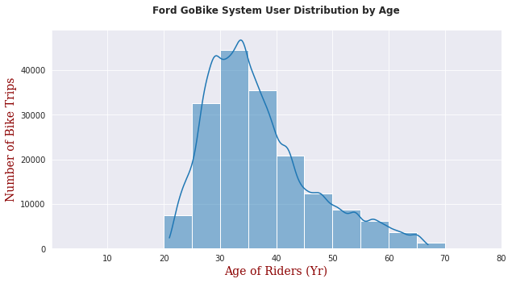

**Observation**: From the graph , it can be observed that the mean age is approximately 36 years and the mode is 34 years.

**Gender Distribution**

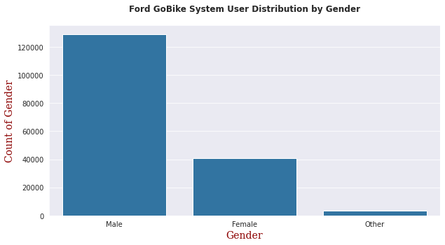

**Observation**: From the graph, it can be observed that more males used the ride sharing service

**User Type Distribution**

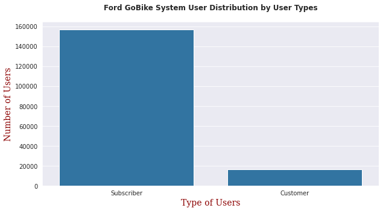

**Observation**: It can be seen that subscription based users used the service more

**Distribution by Shared Ride**

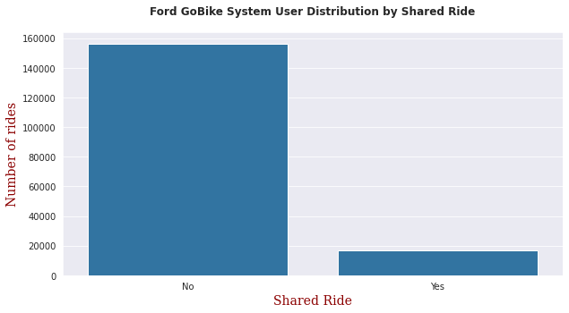

**Observation**: It can be observed that most of the trips were not shared ride

**Distribution by Daily Usage**

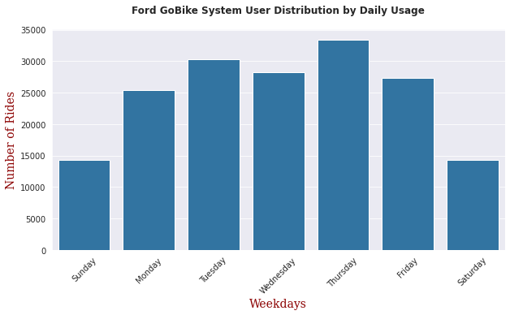

**Obsevation**: From the graph, it can be observed that more bikes trips were on Thursdays

**Distribution by Weekly Usage**

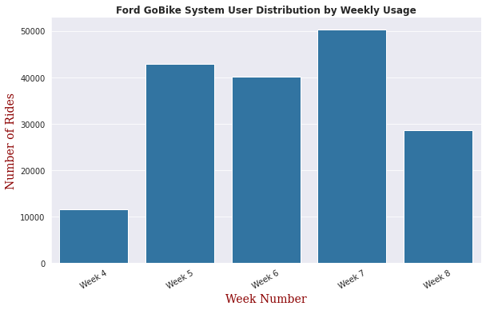

**Observation**: From the graph, it can be observed that Week 7 of the year had the most bike rentals

**Distribution by Hourly Usage**

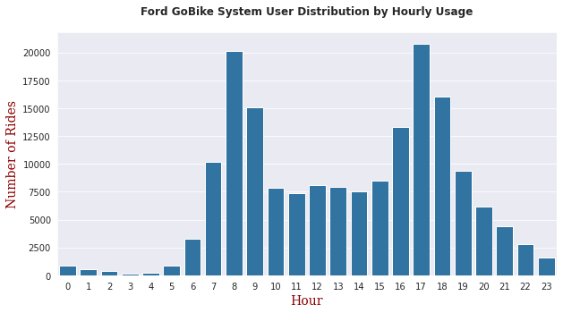

**Observation**: More bikes were rented at the 17th hour followed closely by the 8th hour.

### Discuss the distribution(s) of your variable(s) of interest. Were there any unusual points? Did you need to perform any transformations?

> All transfromations had been done earlier during the cleaning process with more useful variables introduced as columns. During this univariate analysis of data, most the newly introduced columns were not used expect the "start_time_hour" and "age" which was used to visualise the distribution of the rental start time and age of the users. For other variable of interest used, their distribution is discussed below:
> 1. Age: The distribution of the age of the users show that the average age is approximately 36 while the mode of the age is 34.
> 2. Gender: The distribution of the gender of the users show that there were more male users than female and others.
> 3. User Type: The distribution of the user types show that there are more subscription based users than walk in customers.
> 4. Shared Ride: The distribution of the shared ride show that most rides were not shared.
> 5. Days: The distribution of the days show that more rides were made on Thursday compared to the rest of the days while saturday and sundays have the lowest amount of rides in a day.
> 6. Week of the Year: The distribution of the week show that more trips were made on the week 7 of the year which falls on the third week of February. 7.Hours of the Day: The distribution of the hours of the day show that more rides were made at 8am and 5pm daily compared to other hours of the day.

### Of the features you investigated, were there any unusual distributions? Did you perform any operations on the data to tidy, adjust, or change the form of the data? If so, why did you do this?

> For features investigated in this univariate analysis, there was no unusual distribution. I already changed the form of the datasets while cleaning, so I did not need to do so during this analysis.

## Bivariate Exploration

> In this section, investigate relationships between pairs of variables in your data. Make sure the variables that you cover here have been introduced in some fashion in the previous section (univariate exploration).

**Relationship between the distance covered and age of the users**

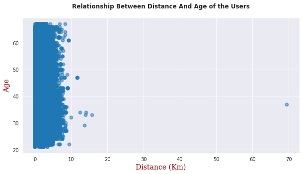

**Observation**: It can be noticed that majority of the ages of users rode within 10 Km.

**Relationship between the cycling speed and the age of riders**

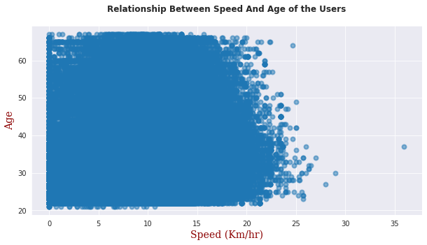

**Observation**: It can be observed that majority of the ages of riders cycled at a speed below 25km/hr

**Relationship between the time taken by riders and the age of riders**

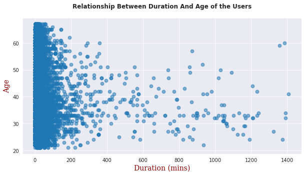

**Relationship between the age of the riders and the gender of users**

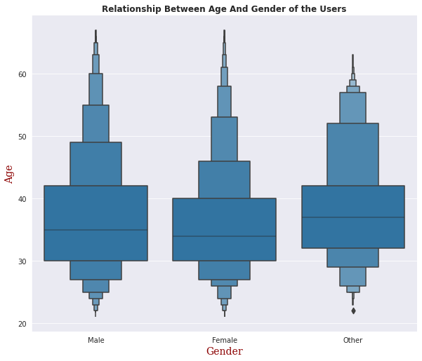

```
member_gender
Male      30.0
Female    30.0
Other     32.0
Name: age, dtype: float64 member_gender
Male      35.0
Female    34.0
Other     37.0
Name: age, dtype: float64 member_gender
Male      42.0
Female    40.0
Other     42.0
Name: age, dtype: float64
```

**Observation**: From the plot the following can be observed:

1. In the 25th percentile, the age of the male and female riders are the same but that of others differ
2. In the 50th percentile, the age of all categories of gender varies from one another
3. in the 75th percentile, the age of male and others are the same while that of the female is lower

**Relationship between type of users and age of users**

[figure not shown]

```
user_type
Subscriber    30.0
Customer      30.0
Name: age, dtype: float64 user_type
Subscriber    35.0
Customer      35.0
Name: age, dtype: float64 user_type
Subscriber    42.0
Customer      41.0
Name: age, dtype: float64
```

Observation: From the plot, it can be observed that the there is not much difference in the percentiles of the age of the subscriber and customer except in 75th percentile where the age is 42 and 41 for the subscriber and customer respectively

**Relationship between start/end hours and the user_type**

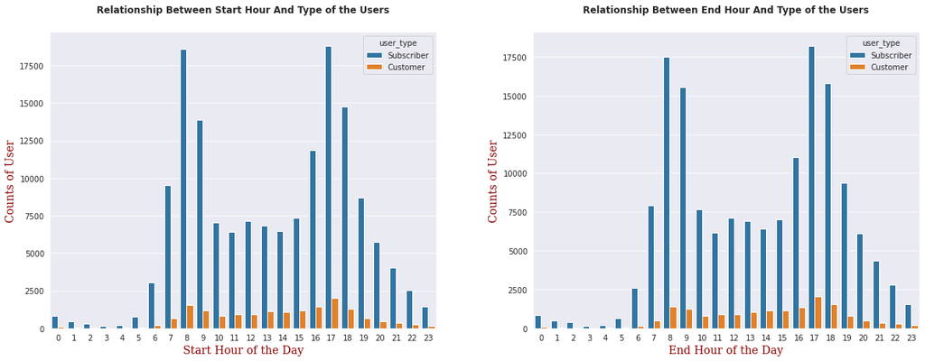

Observation: From both plot, it can be observed that more trips by the two category of users started at 8 and 17 hours which are basically resumption and closing periods of workers. So, it can be deduced that most of the users are likely working class.

**Relationship between Start/End Hour and genders of riders**

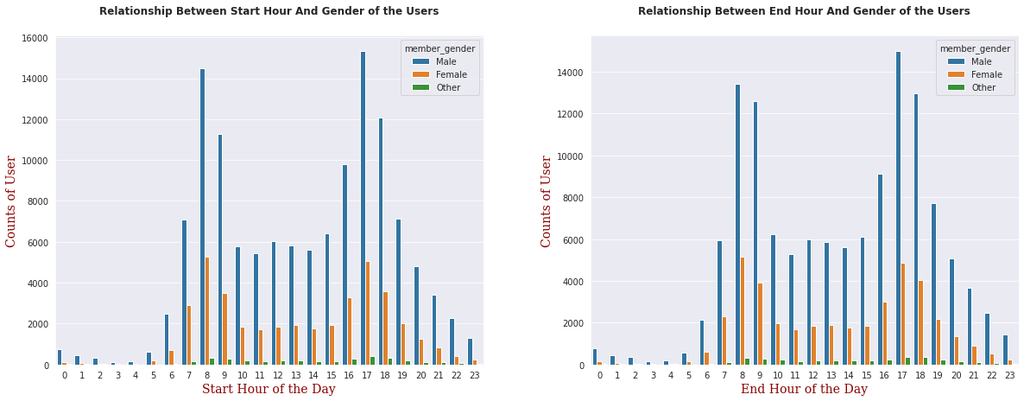

Observation: From both plot, it can be observed that more trips by the three category of genders started at 8 and 17 hours

### Did you observe any interesting relationships between the other features (not the main feature(s) of interest)?

> None

## Multivariate Exploration

> Create plots of three or more variables to investigate your data even further. Make sure that your investigations are justified, and follow from your work in the previous sections.

**What is the daily average speed of the two category of users**

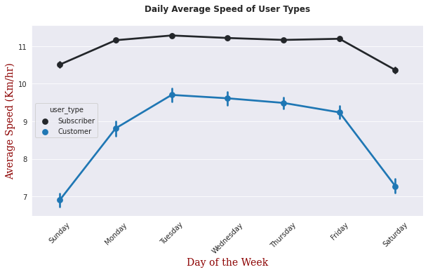

**Observation**: From the plot, it can be observed that subscribers ride faster than customers on the average.

**What is the daily average distance covered by the two category of user?**

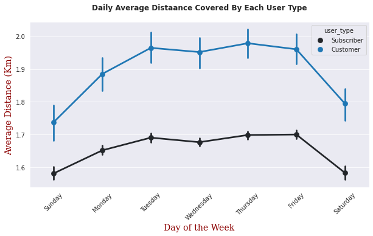

**Observation**: From the plot, it can be observed that customers travel a longer distance than subscribers on the average. This implies that:

1. The subscribers only use the bike for short trips
2. The customers use the bike for long trips

**What is the daily average duration spent by the two category of user?**

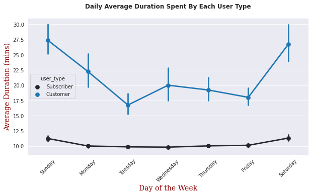

**Observation**: From the plot, it can be observed that customers spend more time daily riding than subscribers on the average.

**Relationship between users, weekdays, weekends and the number of trips taken**

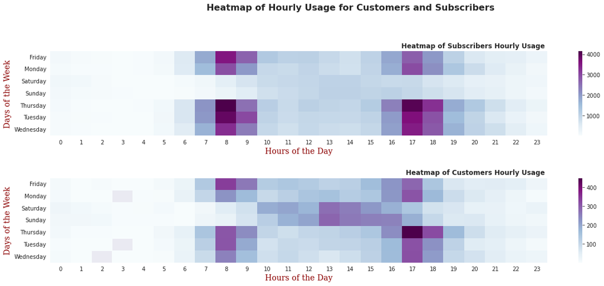

**Observation**: From the heatmap, the following observations were made:

1. Like earlier observed in the bivariate analysis between hours and user types, it can also been seen that there are heavy usage of the bikes in the 8th, 9th, 17th and 18th hour of the day.
2. For Subscribers, there is very low usage of bikes on Saturdays and Sundays implying that the subscribers are majorly workers within the Greater San Francisco Bay Area
3. For customers, there is high activities between the hours 13 - 15 on saturdays and sundays implying that customers are majorly people who take the ride for leisures and might actually be tourists within the Greater San Francisco Bay Area

### Talk about some of the relationships you observed in this part of the investigation. Were there features that strengthened each other in terms of looking at your feature(s) of interest?

> 1. Yes! Patterns observed in the univariate and bivariate parts of the analysis were further strengthened by the multivariate analysis. In the multivariate analysis, it could be notice that the subscribers are majorly workers as this reflect in the pattern of the bike usage - they use the bike more during weekdays. For the custoemrs, their pattern of usage shows that of leisure and fun seeking and it can deduced that they are tourists in the city.
> 2. The analysis also show that the customers tend to ride slower over a longer distance for a longer period of time compared to the subscribers who ride faster for a shorter period time over a shorter distance enforcing the belief that the subscribers are workers while the customers are tourists.

### Were there any interesting or surprising interactions between features?

> There was no suprising interactions between the features as they all complemented one another as expected.

## Conclusions

> In this investigation, we were able to use the riding pattern of the two category of users to determine their lifetyle.